# Making an intentionally biased random walk

# Preamble

One of the more celebrated Markov chains is the simple random walk on the integers: from where you are on the number line, with probability 0.5 you take a step of length 1 to the left, and with probability 0.5 you take a step of length 1 to the right.

Often, this walk is envisioned on the unbounded integers, but for our purposes, we will want to restrict it to fewer numbers. So, we will restrict it to the numbers $1,\ldots,20$.

Now, let us write a function that starts from anywhere within $[1,\ldots,20]$ and does this random walk for `steps` steps. Because we have restricted the walk, we will have to do something a little fancy: if our random walk tries to step beyond 1 or 20, we will just “slap its hand” and tell it to stay where it currently is (either 1 or 20) for a step.

Here is a function. We will write it so that we can change the left and right boundaries if we want.

```r
#' @param init starting value.  Must be an integer between left and right inclusive
#' @param steps the number of steps to take in the random walk
#' @param left the left boundary of the walk
#' @param right the right boundary of the walk
rando_walk <-  function(init, steps, left = 1, right = 20) {

  out <- rep(NA, steps + 1)  # to store the output
  out[1] <- init  # start at the initial state

  for (i in 2:steps) {
    step <- sample(c(-1, 1), 1)  # choose if the step is to the left or right
    proposed <- out[i - 1] + step

    if (proposed < left || proposed > right) {
      out[i] <- out[i - 1]
    } else {
      out[i] <- proposed
    }
  }
  out
}
```

Study the code. Note that because we have to do something fancy at the boundary, we don’t just blindly take a step up (1) or down (-1), but rather we see where we would be stepping—in other words where we are *proposing* to step—and then we decide whether or not we should step there. If we don’t step there (because it is out of bounds) we just stay where we are and do not take a step at all.

Let’s run that random walk for one million iterations and see how much time is spent in the different states:

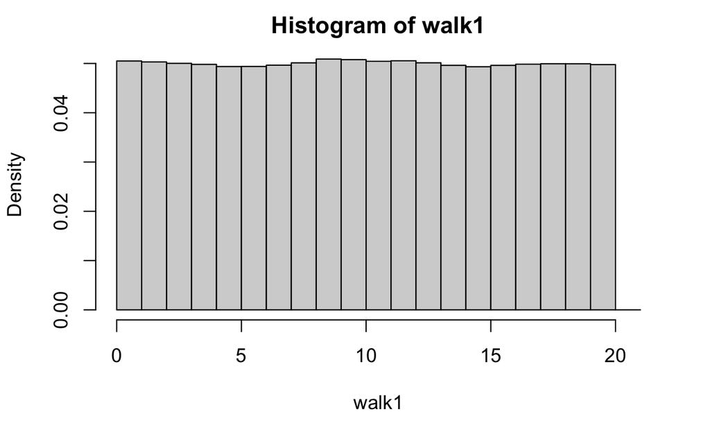

```r
# do the walk!
walk1 <- rando_walk(
  init = 5,
  steps = 1e6
)

# tabulate and plot the proportion of time the
# walk spends in each of the 20 states
hist(walk1, breaks = 0:21, freq = FALSE)
```

Cool! That looks pretty close to a uniform distribution, which is what we might expect for such a random walk.

# What if we wanted a different limiting distribution?

Suppose now that you wanted to tweak the random walk so that it spent more time in some states than in others. In fact, let’s just randomly make a distribution…actually we will make something that looks like a distribution, but is not normalized to sum to one. We will call this `target`

```r
# make a totally random target distribution, but set the seed for reproducibility
set.seed(123)
target <- floor(runif(20, min = 300, max = 1000))
names(target) <- 1:20

# I made them integers...
# have a look at this thing:
target
```

```
  1   2   3   4   5   6   7   8   9  10  11  12  13  14  15  16  17  18  19
501 851 586 918 958 331 669 924 686 619 969 617 774 700 372 929 472 329 529
 20
968
```

And, now, plot it:

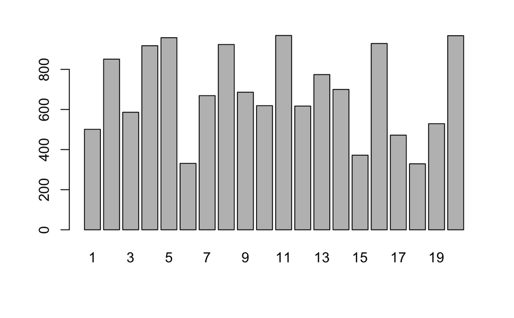

```r
barplot(target)
```

That is definitely *not* proportional to a uniform distribution.

# A normalized distribution

It might be nice to have a normalized distribution (one that sums to one) that `target` is proportional to.

## Exercise 1

Create such a normalized distribution here. I have some code, leaving “your_code_here” where you need to fill it in

```r
normo_target <- "your_code_here"

# now plot it, (uncomment the following line once you have put your code in)
# barplot(normo_target)
```

## Exercise 2

Now that you have determined the normalized target distribution, use `normo_target` to sample the integers from 1:20 using regular old Monte Carlo (independent samples) having that distribution using the `sample` function. Sample 1 million of them and plot the result. It should look almost identical to `normo_target`

```r
# your code here...
```

# What about making a random walk that has `normo_target` as its limiting distribution?

Think about this, if you were to start with a simple random walk, but “tweak” it so that it had a limiting distribution that was proportional to `target` what might you do? Well, one thought is that you would “nudge” the walk so that it is more likely to go step to states with high probability in the target than to states with low probability in the target.

There is one approach that depends only on comparing the height of the current state in `target` to the height of where you are proposing to move to. The recipe goes like this:

- From the current state propose going up 1 or down 1.
- If the proposed state is out of bounds, then reject the proposal and stay where you are (`out[i] <- out[i - 1]`)
- If the proposed state has a *higher* value in `target` than the current state, accept this proposal and move there (i.e. `out[i] <- proposed`).
- If the proposed state has a *lower* value in target than the current state, then you do not automatically accept it. Rather, you accept it according to the differences between the values of the current and proposed states in `target`. Specifically, you accept the proposal with probability equal to

```
target(proposed) / target(current)
```

For example, draw a uniform random number between 0 and 1, and if that value is less than `target(proposed) / target(current)` you accept the proposal, and `out[i] <- proposed`.

That is all there is to it.

## Exercise 3

Implement the biased random walk described above. For a skeleton I have put the unbiased random walk in there. You need to fill in some more details

```r
#' @param init starting value.  Must be an integer between left and right inclusive
#' @param steps the number of steps to take in the random walk
#' @param target a vector of unnormalized (if desired) probabilities
#' @param left the left boundary of the walk
#' @param right the right boundary of the walk
targeted_rando_walk <-  function(init, steps, target, left = 1, right = 20) {

  out <- rep(NA, steps + 1)  # to store the output
  out[1] <- init  # start at the initial state

  for (i in 2:steps) {
    step <- sample(c(-1, 1), 1)  # choose if the step is to the left or right
    proposed <- out[i - 1] + step

    if (proposed < left || proposed > right) {
      out[i] <- out[i - 1]
    } else if (target[proposed] >= target[out[i - 1]]) {
      # you fill in some code here!
    } else if (target[proposed] < target[out[i - 1]]) {
      # you fill in some code here!
    }
  }
  out
}
```

Now, try running it for a million steps using the unnormalized `target` as the target.

Make a histogram of the result. It should look just like the normalized `target`. If it doesn’t there is an error somewhere. To see a completed function that works, go to https://eriqande.github.io/2020-sisg-mcmc-exercises-eca/006-key.nb.html

A big note: realize that you never actually had to normalize the target distribution in order to use it to create a random walk that let’s you sample from it. This turns out to be a huge feature of this approach. Matthew will tell you about it in the next session.